**AI for Mechanical Engineering: Solid Mechanics**

By Sebin Lee  
http://iailab.kaist.ac.kr/  
Industrial AI Lab at KAIST

# 1. Stress-strain Curve

**Tensile Test**

Tensile testing is a destructive test process that provides information about the tensile strength, yield strength, and ductility of the metallic material.

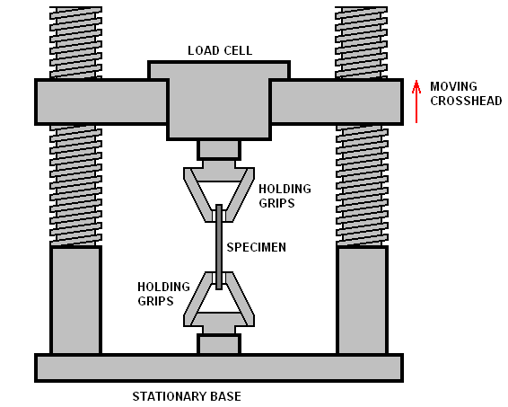

**Stress-strain Curve**

The tensile test result can be represented as a stress-strain curve, which shows the relationship between stress and strain.

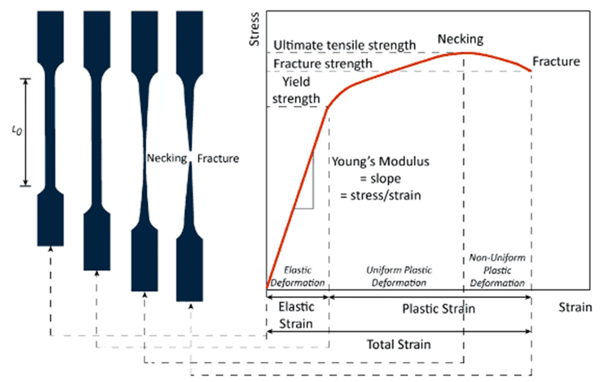

Some of the major properties in stress-strain curve

- **Young’s modulus**: Relationship between tensile stress and axial strain in the linear elastic region
- **Yield strength**: Stress corresponding to the yield point
- **Ultimate tensile strength**: The maximum stress that a material can withstand while being stretched

**How to find Young's modulus from the stress-strain curve**

- Young's modulus is the slope of the stress-strain curve in the elastic region
- We can caculate the slope using linear regression

## 1.1. Linear Regression

Recall linear regression

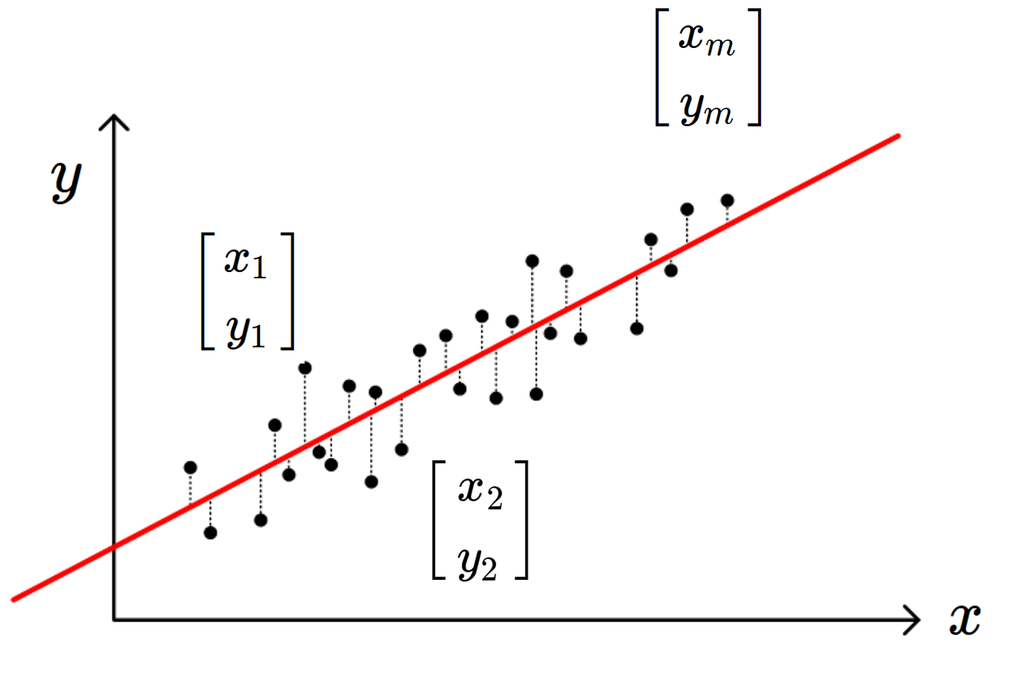

$\text{Given} \; \begin{cases} x_{i} \; \text{: inputs} \\ y_{i} \; \text{: outputs} \end{cases}$ , Find $\theta_{0}$ and $\theta_{1}$

$$x= \begin{bmatrix} x_{1} \\ x_{2} \\ \vdots \\ x_{m} \end{bmatrix}, \qquad y= \begin{bmatrix} y_{1} \\ y_{2} \\ \vdots \\ y_{m} \end{bmatrix} \approx \hat{y}_{i} = \theta_{0} + \theta_{1}x_{i}$$

- $ \hat{y}_{i} $ : predicted output
- in many cases, a linear model is used to predict $y_{i}$

$$ \hat{y}_{i} = \theta_{0} + \theta_{1}x_{i} \; \quad \text{ such that }\quad \min\limits_{\theta_{0}, \theta_{1}}\sum\limits_{i = 1}^{m} (\hat{y}_{i} - y_{i})^2$$

- Optimization problem

$$\min\limits_{\theta_{0}, \theta_{1}}\sum\limits_{i = 1}^{m} (\hat{y}_{i} - y_{i})^2 =\min\limits_{\theta}\lVert\Phi\theta-y\rVert^2_2 \qquad \qquad \left(\text{same as} \; \min_{x} \lVert Ax-b \rVert_2^2 \right)$$

$$ \text{solution} \; \theta^* = (\Phi^{T}\Phi)^{-1}\Phi^{T} y $$

## 1.2. Young’s Modulus with Linear Regression

Find Young's modulus from tensile test data using linear regression

**Dataset Preparation**

Download tensile test data for aluminum 6061-T651

- [Tensile test data_aluminum 6061-T651_T20](https://drive.google.com/file/d/1koqAEWIKyEnbhRteu7tvdSr-MBz6nkEu/view?usp=sharing)
- [Tensile test data_aluminum 6061-T651_T200](https://drive.google.com/file/d/1LBqpUWqDb6yqcRn-Vk3GC6HrWsCmfujP/view?usp=sharing)

```python
import numpy as np
import matplotlib.pyplot as plt
from sklearn import linear_model
```

```python
data = np.loadtxt('T_020_A_1_001_022_03.csv', delimiter=',', skiprows=1)
data = data[:data.shape[0]-1,:]
```

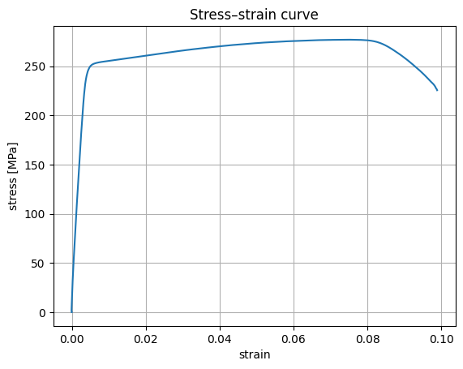

```python
plt.plot(data[:,0],data[:,1])
plt.xlabel('strain')
plt.ylabel('stress [MPa]')
plt.title('Stress–strain curve')
plt.grid('on')
```

Use linear algebra for linear regression

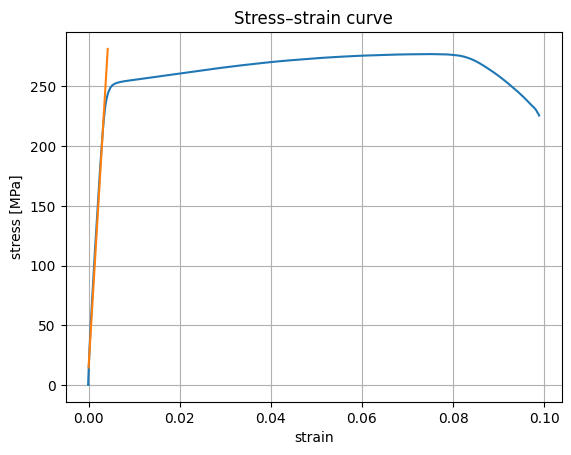

```
Youngs modulus: 63.49[GPa]
```

```python
elastic_data = data[:101,:]
x = elastic_data[:,0].reshape(-1,1)
y = elastic_data[:,1].reshape(-1,1)

A = np.hstack([x**0, x])
A = np.asmatrix(A)

theta = (A.T*A).I*A.T*y

xp = np.arange(data[0,0], data[yield_index,0], 0.0001).reshape(-1, 1)
yp = theta[0,0] + theta[1,0]*xp

plt.plot(data[:,0],data[:,1])
plt.plot(xp, yp)

plt.xlabel('strain')
plt.ylabel('stress [MPa]')
plt.title('Stress–strain curve')
plt.grid('on')
plt.show()

print('Youngs modulus: {:.2f}[GPa]'.format(theta[1,0]/1000))
```

Use Scikit-Learn module for linear regression

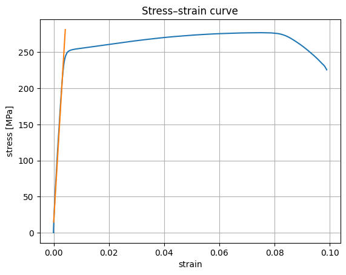

```
Youngs modulus: 63.49[GPa]
```

```python
elastic_data = data[:yield_index,:]
x = elastic_data[:,0].reshape(-1,1)
y = elastic_data[:,1].reshape(-1,1)

reg = linear_model.LinearRegression()
reg.fit(x, y)

xp = np.arange(data[0,0], data[yield_index,0], 0.0001).reshape(-1, 1)

plt.plot(data[:,0],data[:,1])
plt.plot(xp, reg.predict(xp))

plt.xlabel('strain')
plt.ylabel('stress [MPa]')
plt.title('Stress–strain curve')
plt.grid('on')
plt.show()

print('Youngs modulus: {:.2f}[GPa]'.format(reg.coef_[0][0]/1000))
```

## 1.3. Young’s Modulus and Temperature

```python
data = np.loadtxt('T_200_A_1_094_041_14.csv', delimiter=',', skiprows=1)
data = data[:data.shape[0]-1,:]
```

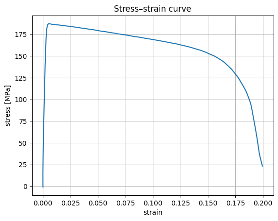

```python
plt.plot(data[:,0],data[:,1])
plt.xlabel('strain')
plt.ylabel('stress [MPa]')
plt.title('Stress–strain curve')
plt.grid('on')
```

Use linear algebra for linear regression

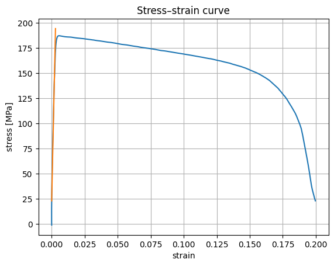

```
Youngs modulus: 59.00[GPa]
```

```python
elastic_data = data[:37,:]
x = elastic_data[:,0].reshape(-1,1)
y = elastic_data[:,1].reshape(-1,1)

A = np.hstack([x**0, x])
A = np.asmatrix(A)

theta = (A.T*A).I*A.T*y

xp = np.arange(data[0,0], data[yield_index,0], 0.0001).reshape(-1, 1)
yp = theta[0,0] + theta[1,0]*xp

plt.plot(data[:,0],data[:,1])
plt.plot(xp, yp)

plt.xlabel('strain')
plt.ylabel('stress [MPa]')
plt.title('Stress–strain curve')
plt.grid('on')
plt.show()

print('Youngs modulus: {:.2f}[GPa]'.format(theta[1,0]/1000))
```

Use Scikit-Learn module for linear regression

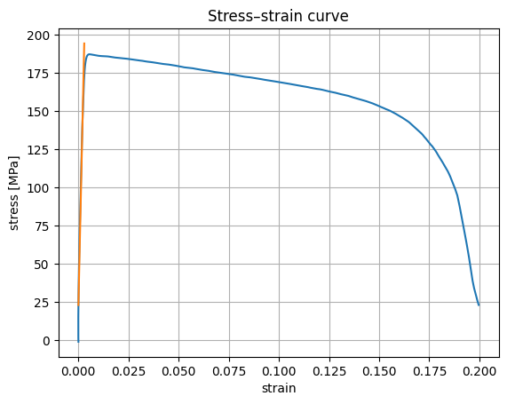

```
Youngs modulus: 59.00[GPa]
```

```python
elastic_data = data[:yield_index,:]
x = elastic_data[:,0].reshape(-1,1)
y = elastic_data[:,1].reshape(-1,1)

reg = linear_model.LinearRegression()
reg.fit(x, y)

xp = np.arange(data[0,0], data[yield_index,0], 0.0001).reshape(-1, 1)

plt.plot(data[:,0],data[:,1])
plt.plot(xp, reg.predict(xp))

plt.xlabel('strain')
plt.ylabel('stress [MPa]')
plt.title('Stress–strain curve')
plt.grid('on')
plt.show()

print('Youngs modulus: {:.2f}[GPa]'.format(reg.coef_[0][0]/1000))
```

# 2. Vibration Signal of Beam

## 2.1. Data Analysis

### 2.1.1. Data in Industry

Detection of abnormal data prevents major accidents by detecting defects in machines or structures in the industrial field

Non-destructive testing finds internal defects or cracks without damaging the inspected system

- Ultrasonic Testing
- Magnetic Particle Testing
- Eddy Current Testing

### 2.1.2. Vibration Signals of Beam

Consider a system composed of a beam and masses

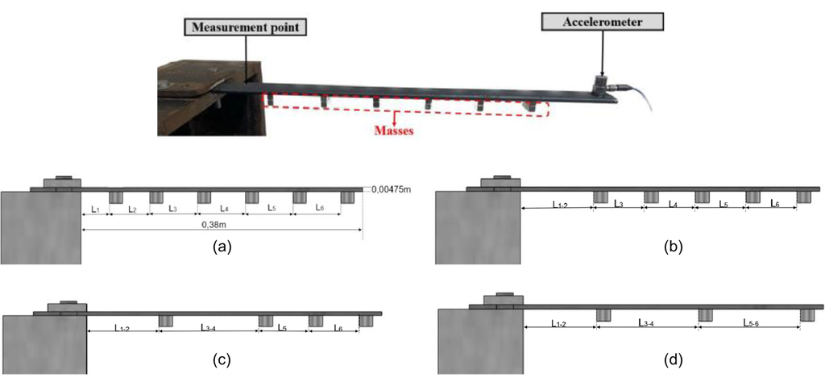

The beam is reinforced with masses under four different conditions

(a) All six masses attached

(b) The mass at position L1 is removed

(c) Masses at positions L1 and L3 are removed

(d) Masses at positions L1, L3 and L5 are removed

**Vibration Signal**

- 70 experiments for each condition
- 6400 data points for each experiment
- Data size (70*4, 6400)

This high dimensional data requires dimension reduction

Let's use PCA dimension reduction!

## 2.2. PCA Dimension Reduction

Recall PCA dimension reduction

Dimension reduction without losing too much information

- Highly correlated data contains redundant features
- Find a low-dimensional, yet useful representation of the data
- Data $\rightarrow$ projection onto unit vector $\hat{u}_1$

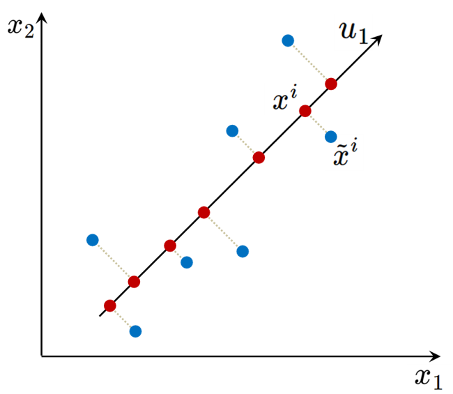

Roughly speaking, PCA does a change of axes that can represent the data in a succinct manner

- Maximize variance (most separable)
- Minimize the sum-of-squares (minimum squared error)

**Pictorial summary of PCA**

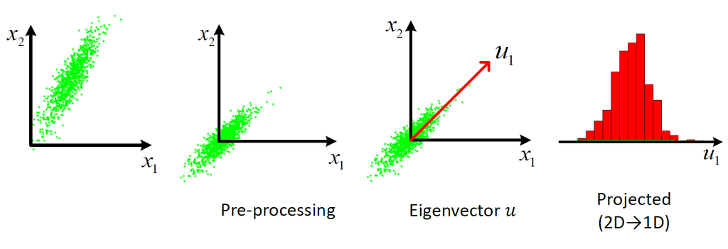

## 2.3. Python Code

### 2.3.1. Data Preparation

Download vibration signal data

- [class_a](https://drive.google.com/file/d/1zHEuMD35-BMmuxQMhryXNOf1Vrx0quGi/view?usp=sharing)
- [class_b](https://drive.google.com/file/d/1XB4SJ06DONZv3kBs0FImjNuvqpqe6OFj/view?usp=sharing)
- [class_c](https://drive.google.com/file/d/1C5V1XJhfpITzlGnn0nJKNwRTjnURM04C/view?usp=sharing)
- [class_d](https://drive.google.com/file/d/19hEvCQMNfAVicrhNwcvt-gRR2x3O6VK_/view?usp=sharing)

```python
from google.colab import drive
drive.mount('/content/drive')
```

```python
import numpy as np
from sklearn.decomposition import PCA
import matplotlib.pyplot as plt
```

```python
class_a = np.load('/content/drive/MyDrive/Colab Notebooks/AI for ME/수업자료/class_a.npy')
class_b = np.load('/content/drive/MyDrive/Colab Notebooks/AI for ME/수업자료/class_b.npy')
class_c = np.load('/content/drive/MyDrive/Colab Notebooks/AI for ME/수업자료/class_c.npy')
class_d = np.load('/content/drive/MyDrive/Colab Notebooks/AI for ME/수업자료/class_d.npy')

# class_a = np.load('class_a.npy')
# class_b = np.load('class_b.npy')
# class_c = np.load('class_c.npy')
# class_d = np.load('class_d.npy')
```

```python
total_data = np.concatenate((class_a, class_b, class_c, class_d), axis = 0)
print(total_data.shape)
```

```
(280, 6400)
```

- Note that the dimension of the data is very high

```python
label = np.zeros(280)
label[70:140] = 1
label[140:210] = 2
label[210:] = 3
print(label.shape)
```

```
(280,)
```

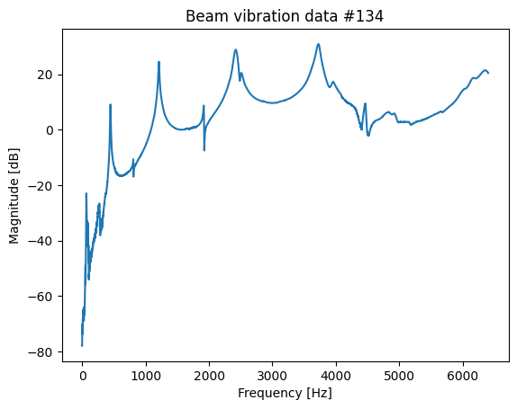

```python
# Plot sample data

i = np.random.randint(280)
plt.plot(total_data[i])
plt.xlabel('Frequency [Hz]')
plt.ylabel('Magnitude [dB]')
plt.title('Beam vibration data #{}'.format(i))
```

### 2.3.2. PCA: 1D

```python
pca = PCA(n_components=1)
pca_data = pca.fit_transform(total_data)
```

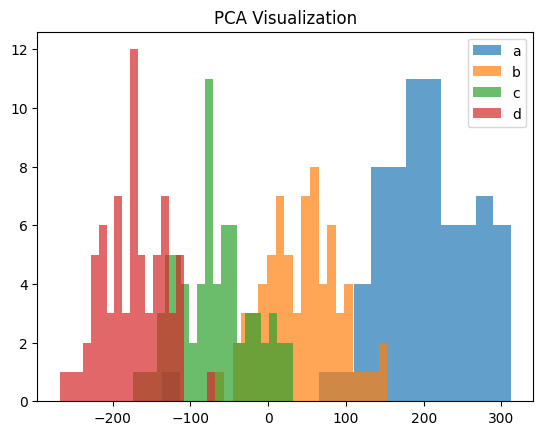

```python
plt.title('PCA Visualization')
plt.hist(pca_data[:70], bins=20, label='a', alpha=0.7)
plt.hist(pca_data[70:140], bins=20, label='b', alpha=0.7)
plt.hist(pca_data[140:210], bins=20, label='c', alpha=0.7)
plt.hist(pca_data[210:], bins=20, label='d', alpha=0.7)
plt.legend()
```

### 2.3.3. PCA: 2D

```python
pca = PCA(n_components=2)
pca_data = pca.fit_transform(total_data)
```

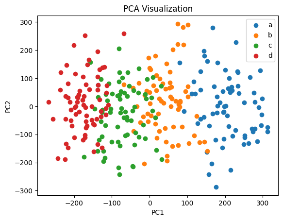

```python
plt.title('PCA Visualization')
plt.scatter(pca_data[:70,0], pca_data[:70,1], label='a')
plt.scatter(pca_data[70:140,0], pca_data[70:140,1], label='b')
plt.scatter(pca_data[140:210,0], pca_data[140:210,1], label='c')
plt.scatter(pca_data[210:,0], pca_data[210:,1], label='d')

plt.xlabel('PC1')
plt.ylabel('PC2')
plt.legend()
```

```python
eigenvalues = pca.explained_variance_
print('Eigen value for PC1: {:.2f}'.format(eigenvalues[0]))
print('Eigen value for PC2: {:.2f}'.format(eigenvalues[1]))
```

```
Eigen value for PC1: 22106.92
Eigen value for PC2: 11954.49
```

# 3. PINN Beam

## 3.1. Deflection of Beams

From solid mechanics, beam deflection follows the second-order differential equation below

$${\partial^2 y \over \partial x^2} = {M(x) \over EI}$$

Where

- M: Bending moment
- E: Modulus of elasticity
- I : Moment of inertia

Under some boundary conditions, we can accurately calculate the deflection of the beam

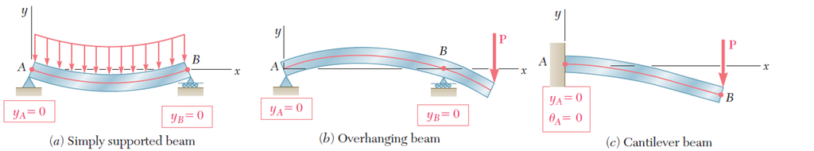

## 3.2. Euler Beam Example

Recall PINN example about Euler Beam

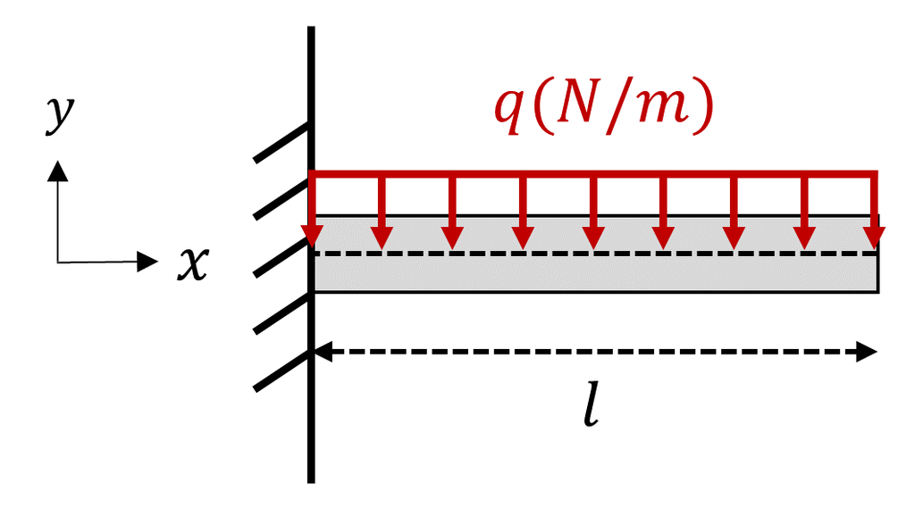

- Problem properties

$$E = 1 \operatorname{pa}, \quad I = 1 \operatorname{kg\cdot m^2}, \quad q = 1 \operatorname{N/m}, \quad l = 1 \operatorname{m}$$

Make a neural network and loss functions like below :

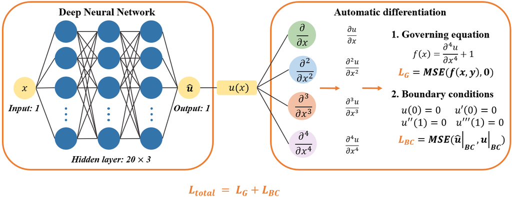

PINN prediction

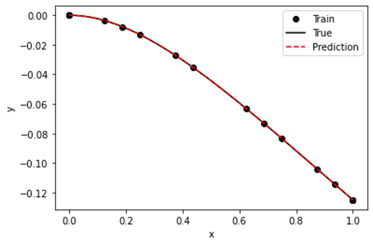

## 3.3. Deflection of Beams with Point Forces

Solve beam deflection with different conditions

- Point forces instead of distributed forces
- Fixed points located in the middle of the beam

### 3.3.1. Overhang Beam Example

Solve following example

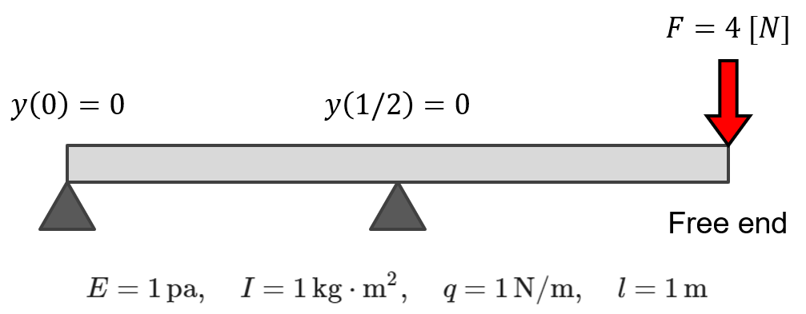

- Partial differential equations

$${\partial^2 y \over \partial x^2} = {M(x) \over EI}$$

- Exact solution

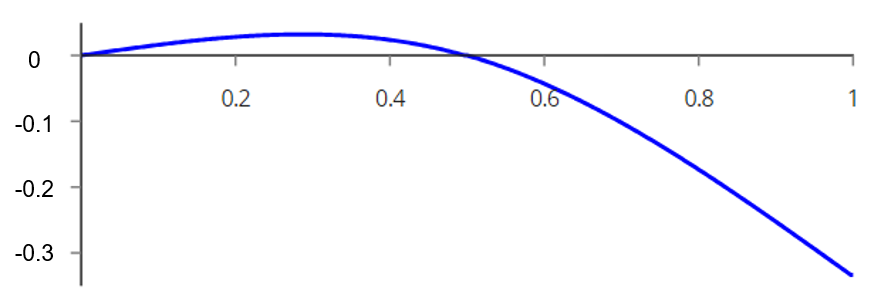

### 3.3.2. Dynamic Analysis of Beam

- Force distribution
  - Torque at $ x=0 $ is 0

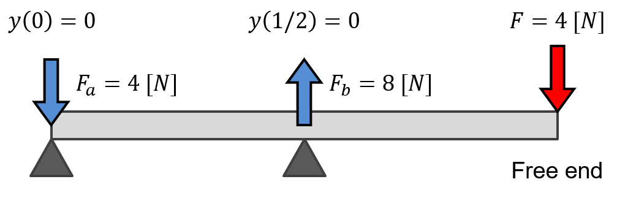

- Bending moment

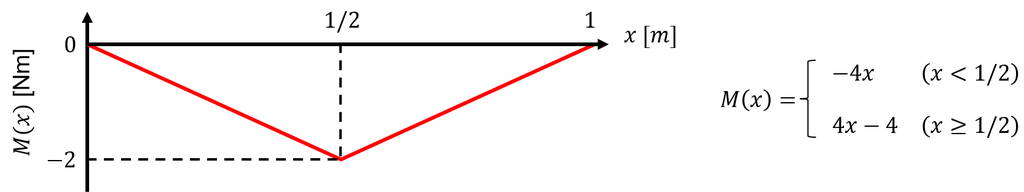

Can be written as

$$ M(x) = -4x + 8 (x-1/2) u(x-1/2) $$

Where $ u(x) $ is a unit step function.

- PDE for PINN

$${\partial^2 y \over \partial x^2} = {M(x) \over EI} = - 4x + 8 (x-1/2) u(x-1/2) $$

$${\partial^2 y \over \partial x^2} + 4x - 8 (x-1/2) u(x-1/2) = 0 $$

## 3.4. PINN with Point Forces

### 3.4.1. Prepare Deepxde Module

```python
!pip install deepxde
```

```
     ━━━━━━━━━━━━━━━━━━━━━━━━━━━━━━━━━━━━━━━━ 182.2/182.2 kB 1.3 MB/s eta 0:00:00
     ━━━━━━━━━━━━━━━━━━━━━━━━━━━━━━━━━━━━━━━━ 107.7/107.7 kB 5.7 MB/s eta 0:00:00
```

```python
import deepxde as dde
import numpy as np
from deepxde.backend.set_default_backend import set_default_backend
set_default_backend("tensorflow")
import tensorflow as tf
```

```
No backend selected.
Finding available backend...
```

[output not shown]

[output not shown]

### 3.4.2. Define PDE System

```python
# Define unit step function
def step(x,t):
    step_1 = tf.constant(1., dtype=tf.float32)
    step_0 = tf.constant(0., dtype=tf.float32)
    step = tf.where(x>t, step_1, step_0)
    return step
```

```python
def ddy(x, y):
    return dde.grad.hessian(y, x)

def pde(x, y):
    dy_xx = ddy(x, y)
    return dy_xx + 4*x*step(x,0) - 8*(x-1/2)*step(x,1/2)
```

### 3.4.3. Define Boundary Condition

```python
def boundary_left(x, on_boundary):
    return on_boundary and np.isclose(x[0], 0)

def boundary_right(x, on_boundary):
    return on_boundary and np.isclose(x[0], 1)
```

```python
# The fixed point (x=1/2) should be defined as an anchor point
observe_x = np.array([1/2])
observe_y = dde.icbc.PointSetBC(observe_x, 0, component=0)
```

```python
geom = dde.geometry.Interval(0, 1)

bc1 = dde.DirichletBC(geom, lambda x: 0, boundary_left) # u(0) = 0

def true_solution(x):
    return np.where(x < 0.5, -2*(x ** 3)/3 + x/6, 2*(x ** 3)/3 - 2*(x ** 2) + 7*x/6 - 1/6 )

data = dde.data.PDE(geom,
                    pde,
                    [bc1, observe_y],
                    num_domain = 10,
                    num_boundary = 2,
                    anchors=observe_x,
                    solution = true_solution,
                    num_test = 100)
```

### 3.4.4. Define and Train Model

```python
layer_size = [1] + [20] * 3 + [1]
activation = "tanh"
initializer = "Glorot uniform"

net = dde.nn.FNN(layer_size, activation, initializer)
```

```python
model = dde.Model(data, net)
model.compile("adam", lr=0.001)
```

```
Compiling model...
Building feed-forward neural network...
'build' took 0.075960 s
```

```
'compile' took 0.726011 s
```

```
Training model...

Step      Train loss                        Test loss                         Test metric
0         [1.19e+00, 0.00e+00, 2.13e-02]    [1.03e+00, 0.00e+00, 2.13e-02]    []
1000      [1.47e-03, 2.22e-06, 1.02e-06]    [1.92e-03, 2.22e-06, 1.02e-06]    []
2000      [7.39e-04, 6.01e-07, 7.48e-07]    [1.35e-03, 6.01e-07, 7.48e-07]    []
3000      [4.04e-04, 6.05e-08, 6.20e-08]    [1.30e-03, 6.05e-08, 6.20e-08]    []
4000      [3.41e-04, 1.22e-08, 9.40e-09]    [1.22e-03, 1.22e-08, 9.40e-09]    []
5000      [3.07e-04, 4.38e-08, 3.15e-07]    [1.07e-03, 4.38e-08, 3.15e-07]    []

Best model at step 5000:
  train loss: 3.07e-04
  test loss: 1.07e-03
  test metric: []

'train' took 6.076772 s
```

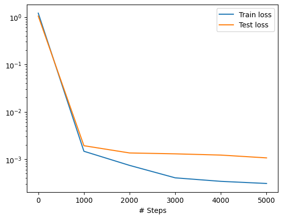

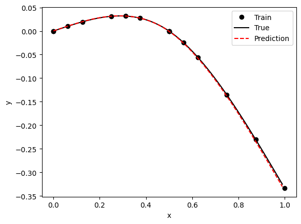

```python
losshistory, train_state = model.train(iterations = 5000)

dde.saveplot(losshistory, train_state, issave = False, isplot = True)
```

# 5. PINN Catenary Cable

## 5.1. Catenary Cable

Catenary is a curve of an ideally hanging cable under it’s weight

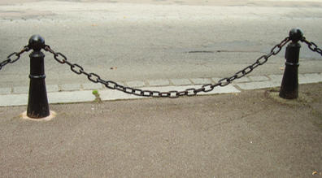

### 5.1.1. Dynamic Analysis of Catenary

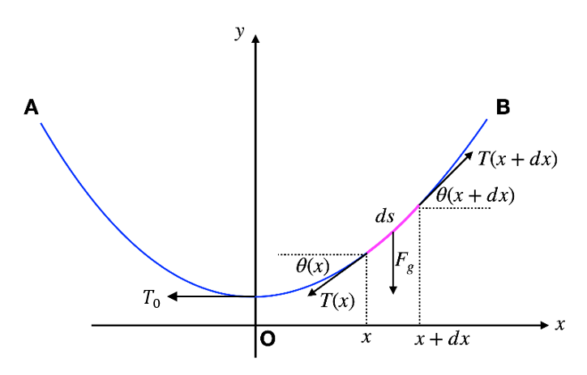

- For small interval $ds$

$$ \Sigma F_x = T(x+dx)\cos(\theta(x+dx)) - T(x)\cos(\theta(x)) = 0$$

$$ \Sigma F_y = T(x+dx)\sin(\theta(x+dx)) - T(x)\sin(\theta(x)) - \omega ds = 0$$

- From x-direction component

$$ T(x)\cos(\theta(x)) = T_0 $$

- From y-direction component

$$ T(x)\sin(\theta(x)) = \omega ds $$

- Therefore,

$$ {dy \over dx} = \tan(\theta(x)) = {\omega ds \over T_0} = {ds \over a} $$

- By substituting this into the formula for arc length

$$ {dy \over dx} = \sinh {x-x_0 \over a} $$

$$ y(x) = a \cosh {x-x_0 \over a} + C $$

### 5.1.2. Catenary Cable Example

Let's assume an example of catenary cable

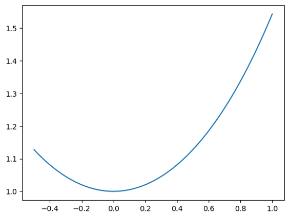

## 5.2.PINN: Catenary Cable

### 5.2.1. Prepare Deepxde Module

```python
!pip install deepxde
```

```
     ━━━━━━━━━━━━━━━━━━━━━━━━━━━━━━━━━━━━━━━━ 182.2/182.2 kB 2.6 MB/s eta 0:00:00
     ━━━━━━━━━━━━━━━━━━━━━━━━━━━━━━━━━━━━━━━━ 107.7/107.7 kB 5.8 MB/s eta 0:00:00
```

```python
import deepxde as dde
import numpy as np
from deepxde.backend.set_default_backend import set_default_backend
set_default_backend("tensorflow")
import tensorflow as tf
import matplotlib.pyplot as plt
```

```
No backend selected.
Finding available backend...
```

[output not shown]

[output not shown]

### 5.2.2. Define PDE System and Boundary Condition

```python
def dy(x, y):
    return dde.grad.jacobian(y, x)

def pde(x, y):
    dy_x = dy(x, y)
    return dy_x - tf.math.sinh(x)
```

```python
def boundary_left(x, on_boundary):
    return on_boundary and np.isclose(x[0], -1/2)

def boundary_right(x, on_boundary):
    return on_boundary and np.isclose(x[0], 1)
```

```python
geom = dde.geometry.Interval(-1/2, 1)

bc1 = dde.DirichletBC(geom, lambda x: np.cosh(-1/2), boundary_left) # u(0) = 0
bc2 = dde.DirichletBC(geom, lambda x: np.cosh(1), boundary_right) # u(0) = 0

def true_solution(x):
     return np.cosh(x)

data = dde.data.PDE(geom,
                    pde,
                    [bc1, bc2],
                    num_domain = 10,
                    num_boundary = 2,
                    solution = true_solution,
                    num_test = 100)
```

### 5.2.3. Define and Train Model

```python
layer_size = [1] + [20] * 3 + [1]
activation = "tanh"
initializer = "Glorot uniform"

net = dde.nn.FNN(layer_size, activation, initializer)
```

```python
model = dde.Model(data, net)
model.compile("adam", lr=0.001)
```

```
Compiling model...
Building feed-forward neural network...
'build' took 0.073666 s
```

```
'compile' took 0.448934 s
```

```
Training model...

Step      Train loss                        Test loss                         Test metric
0         [9.61e-01, 5.94e-01, 4.76e+00]    [1.05e+00, 5.94e-01, 4.76e+00]    []
1000      [2.81e-03, 2.83e-07, 1.57e-08]    [2.08e-03, 2.83e-07, 1.57e-08]    []
2000      [1.25e-03, 1.44e-07, 2.11e-09]    [9.25e-04, 1.44e-07, 2.11e-09]    []
3000      [4.63e-05, 4.51e-08, 1.38e-06]    [3.42e-05, 4.51e-08, 1.38e-06]    []
4000      [3.84e-05, 1.95e-08, 3.98e-09]    [2.85e-05, 1.95e-08, 3.98e-09]    []
5000      [3.42e-05, 1.40e-07, 3.48e-06]    [2.55e-05, 1.40e-07, 3.48e-06]    []

Best model at step 5000:
  train loss: 3.78e-05
  test loss: 2.91e-05
  test metric: []

'train' took 4.001600 s
```

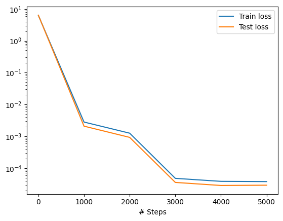

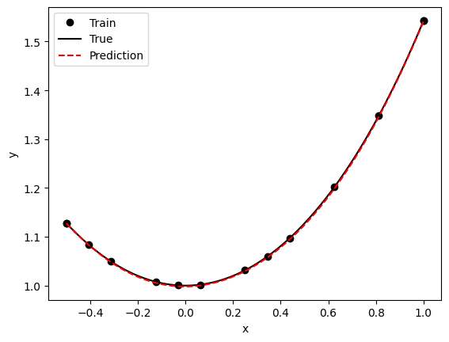

```python
losshistory, train_state = model.train(iterations = 5000)

dde.saveplot(losshistory, train_state, issave = False, isplot = True)
```

### 5.2.4. Model Evaluation

```python
test_x = np.array([[1/2]])

true_y = np.cosh(test_x)
pred_y = model.predict(test_x)

print('True: {0:.5f}'.format(true_y[0][0]))
print('Predict: {0:.5f}'.format(pred_y[0][0]))
print('Error: {0:.5f}'.format(true_y[0][0]-pred_y[0][0]))
```

```
True: 1.12763
Predict: 1.12441
Error: 0.00322
```